# Three Sisters Experiments: Data Wrangling and Analysis

Oscely Acevedo & Annie Tan

2026-10-07

# Introduction

In this lab you will explore how the **Three Sisters agroecosystem** (corn, beans, squash) responds to: - **Nutrient treatments** in the *Main Experiment*  
- **Water treatments (Drought vs Watered)** during the *Heat Wave Experiment*

You will learn to: 1. **Import and wrangle data** 2. **Create growth metrics** for each species  
3. **Make faceted boxplots** comparing growth across systems  
4. **Interpret environmental data** from the heat wave  
5. **Make your own plots**

Throughout this Rmd, **chunks marked with ➤ YOU DO THIS** are student tasks.

# Part 1 — Load Packages and Import Data

```r
library(tidyverse)
library(lubridate)

theme_set(theme_minimal(base_size = 16))

color_vals <- c(
  "Corn"          = "gold",
  "Bean"          = "chartreuse4",
  "Squash"        = "darkorange1",
  "Three Sisters" = "skyblue"
)

drought_color_vals <- c(
  "Drought" = "grey60",
  "Watered" = "black"
)

shape_vals <- c(Drought = 17, Hydrated = 16)

linetype_vals <- c(
  "Nutrient-poor soil" = "solid",
  "Nutrient-rich soil" = "solid",
  "Drought"            = "dotted",
  "Watered"            = "solid",
  "Hydrated"            = "solid"
)

# create a figures directory for use later
dir.create("figures")
bean   <- read_csv("DataCollectionSheets - Bean_Growth.csv")
corn   <- read_csv("DataCollectionSheets - Corn_Growth.csv")
squash <- read_csv("DataCollectionSheets - Squash_Growth.csv")
repr   <- read_csv("DataCollectionSheets - Reproduction.csv")
heat   <- read_csv("drought.csv")
```

# Part 2 — Data Wrangling (Instructor Walkthrough)

## 2.1 Wrangling Bean Growth

Beans have: - **Climb height**  
- **Internode length**  
- **Max node number**

We create a **branch length growth metric**:

```r
bean_grow <- bean %>%
  mutate(
    species = "Bean",
    branch_length_cm = bean_band_len_node1_to4_cm * bean_max_node_number
  )
```

## 2.2 Wrangling Corn Growth

Corn pots had 1–3 plants. We take **mean height per pot**:

```r
corn_grow <- corn %>%
  mutate(
    species = "Corn",
    corn_height_mean = rowMeans(select(., starts_with("corn_height")),
                                na.rm = TRUE)
  )
```

## 2.3 Wrangling Squash Growth

Squash height wasn’t measured. Instead, you measured **length × width** of the 3 largest leaves.

We estimate **leaf area** using an ellipse approximation (× 0.75):

```r
shape_factor <- 0.75

squash_grow <- squash %>%
  mutate(
    species = "Squash",
    leaf1 = S1_leaf_L_cm * S1_leaf_W_cm * shape_factor,
    leaf2 = S2_leaf_L_cm * S2_leaf_W_cm * shape_factor,
    leaf3 = S3_leaf_L_cm * S3_leaf_W_cm * shape_factor,
    growth_proxy_cm2 = pmax(leaf1, leaf2, leaf3, na.rm = TRUE)
  )
```

# Part 3 — Combine Growth Data

We build one dataset with a **unified growth metric**:

```r
growth_all <- bind_rows(
  bean_grow %>% mutate(growth_metric = branch_length_cm),
  corn_grow %>% mutate(growth_metric = corn_height_mean),
  squash_grow %>% mutate(growth_metric = growth_proxy_cm2)
)
```

# Part 4 — Task: Clean for Main Experiment

The main experiment compares: - **Nutrient-poor soil** - **Nutrient-rich soil**

➤ **YOU DO THIS:** Filter `growth_all` for the *Main* experiment.

```r
growth_main <- growth_all %>%
  filter(Experiment == "Main")
```

# Part 5 — Plot: Growth in Main Experiment

Make a faceted boxplot like this:

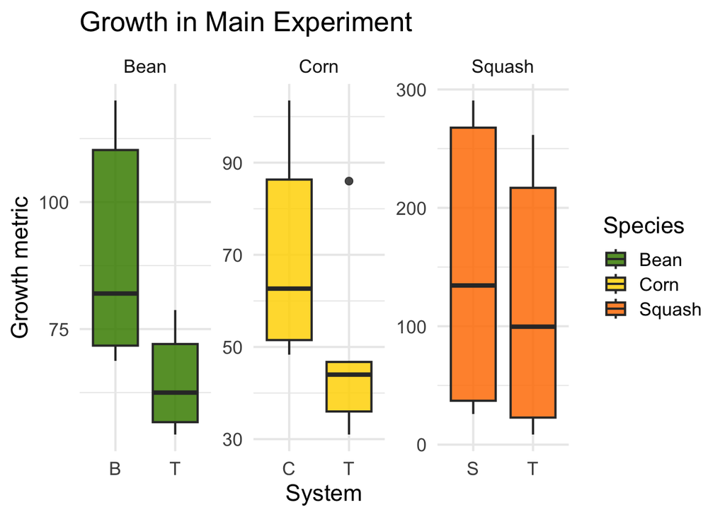

### Save your figure

```r
# Save your plot for use in your full lab report
ggsave("figures/growth_all_plot.png", growth_all_plot, width = 7, height = 5, dpi = 300)
```

➤ **YOU DO THIS:**  
Create your own version of the Main Experiment plot.

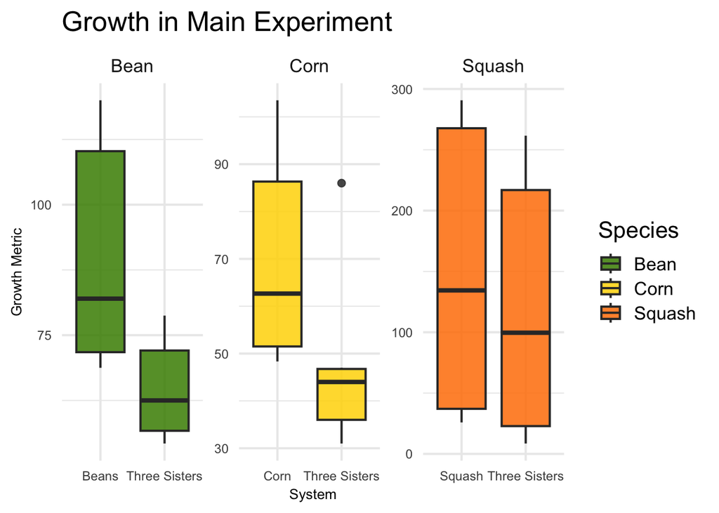

```r
# your code here
new_growth_all_plot <- growth_all %>%
  filter(Experiment == "Main") %>%
  ggplot(aes(x = System,
             y = growth_metric,
             fill = species)) +
  geom_boxplot(alpha = 0.85) +
  scale_fill_manual(values = color_vals,
                    name = "Species") +
  facet_wrap(~ species, scales = "free") +
  labs(
    title = "Growth in Main Experiment",
    x = "System",
    y = "Growth Metric"
  ) +
scale_x_discrete(drop = TRUE, labels = c(
    "Corn"          = "Corn",
    "Bean"          = "Beans",
    "Squash"        = "Squash",
    "Three Sisters" = "Three Sisters"
)
  ) +
  theme(
    axis.text.x = element_text(size = 9),   # smaller x-axis labels
    axis.text.y = element_text(size = 9),   # smaller y-axis labels
    axis.title = element_text(size = 10)    # smaller axis titles
  )

# view the plot

new_growth_all_plot
```

# Part 6 — Explore Reproductive Output

We wrangle reproduction data:

```r
repr_long <- repr %>%
  mutate(
    squash_fruits  = n_s_fruits,
    bean_pods      = n_b_pods,
    corn_ears      = n_c_ears
  ) %>%
  pivot_longer(
    cols = c(squash_fruits, bean_pods, corn_ears),
    names_to = "type",
    values_to = "value"
  )
```

We remove species not present in each system:

```r
repr_clean <- repr_long %>%
  filter(
    (type == "corn_ears"      & System %in% c("Corn", "Three Sisters")) |
    (type == "bean_pods"      & System %in% c("Bean", "Three Sisters")) |
    (type == "squash_fruits"  & System %in% c("Squash", "Three Sisters"))
  ) %>%
  droplevels()
```

➤ **YOU DO THIS:**  
Plot reproductive output by species and system.

[figure not shown]

```r
rep_plot <- ggplot(repr_clean, aes(x = System, y = value, fill = type)) +
  geom_boxplot(alpha = 0.7, outlier.shape = NA) +
  geom_jitter(width = 0.15, alpha = 0.5) +
  scale_fill_manual(
    values = c(
      corn_ears = "#E69F00",
      bean_pods = "#56B4E9",
      squash_fruits = "#009E73"
    ),
    labels = c("Corn ears", "Bean pods", "Squash fruits")
  ) +
  facet_wrap(~ type, scales = "free") +
  labs(
    x = "System",
    y = "Reproductive Output",
    fill = "Species",
    title = "Reproductive Output by Species and System"
  ) +
  theme_bw(base_size = 14
  ) +
  theme(
    axis.text.x = element_text(size = 9),   # smaller x-axis labels
    axis.text.y = element_text(size = 9),   # smaller y-axis labels
    axis.title = element_text(size = 10)    # smaller axis titles
  )


rep_plot
```

```r
ggsave("figures/rep_plot.png", rep_plot, width = 7, height = 5, dpi=300)
```

# Part 7 — Heat Wave Environmetnal Data

## 7.1 Wrangling Heat Wave Growth

```r
# load data
heatwave <- read.csv("drought.csv", stringsAsFactors = T)
heatwave |> mutate( Date = mdy(Date)) -> dat
```

### Summarize heat wave data

```r
heatwave_sum <- heatwave |>
group_by(Date, System, Treatment) |>
summarise(
Temp_mean = mean(Temp...F., na.rm = TRUE),
Temp_se = sd(Temp...F., na.rm = TRUE) / sqrt(dplyr::n()),
Soil_mean = mean(Soil.Moisture, na.rm = TRUE),
Soil_se = sd(Soil.Moisture, na.rm = TRUE) / sqrt(dplyr::n()),
RH_mean = mean(Humidity...., na.rm = TRUE),
RH_se = sd(Humidity...., na.rm = TRUE) / sqrt(dplyr::n()),
.groups = "drop"
)
```

## 7.2 Plot temperature

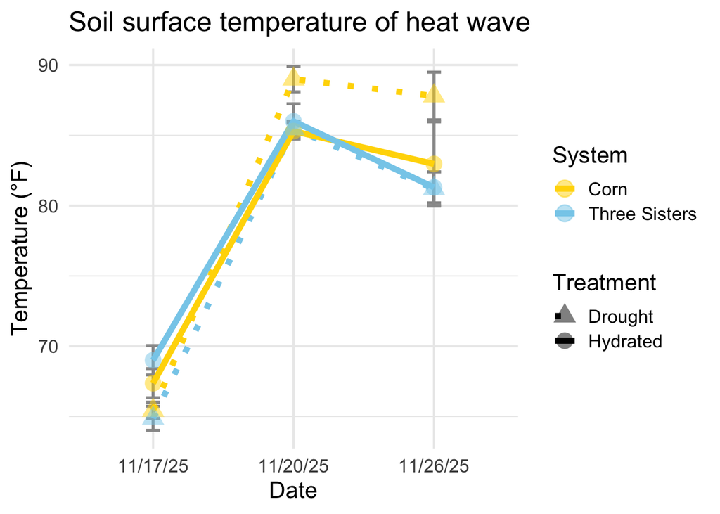

```r
ggplot(heatwave_sum, aes(x = Date, y = Temp_mean,
                    color = System,
                    shape = Treatment,
                    linetype = Treatment,
                    group = interaction(System, Treatment))) +
    geom_errorbar(aes(ymin = Temp_mean - Temp_se,
                    ymax = Temp_mean + Temp_se),
                width = 0.1,
                size = 1,
       color = "gray60",
       linetype = "solid") +
  geom_line(size = 2,
       alpha = 1) +
  geom_point(size = 5,
       alpha = 0.5) +
  scale_color_manual(values = color_vals) +
  scale_shape_manual(values = shape_vals) +
  scale_linetype_manual(values = linetype_vals) +
  labs(title = "Soil surface temperature of heat wave",
       x = "Date", y = "Temperature (°F)")
```

## 7.3 Plot soil moisture

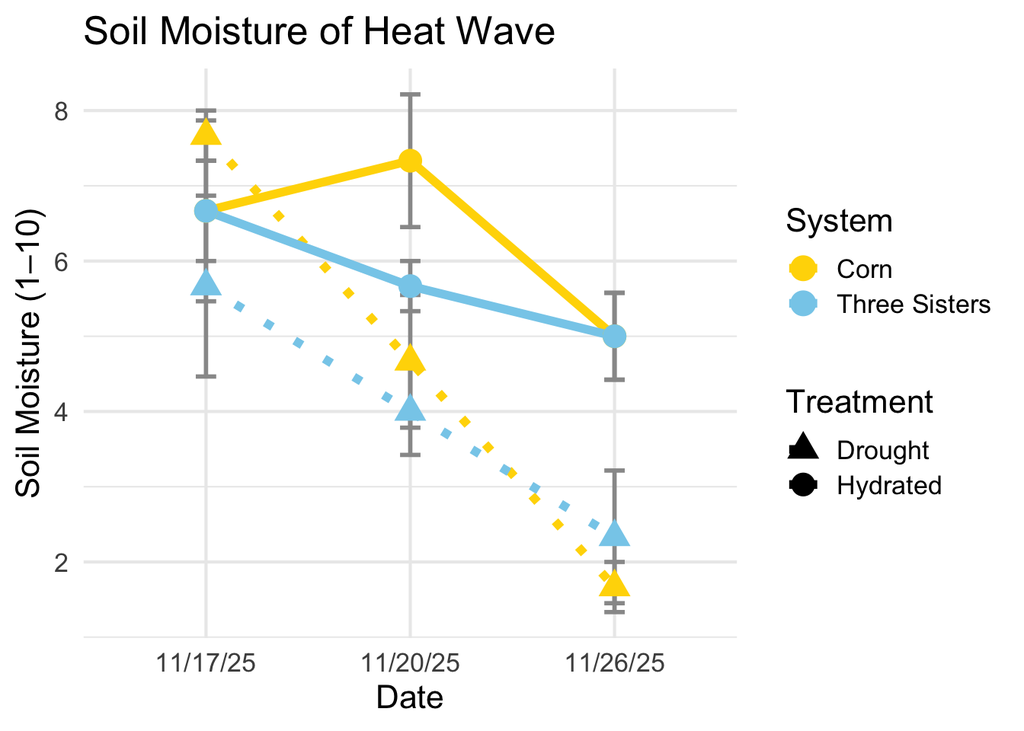

```r
ggplot(
  heatwave_sum,
  aes(
    x = Date,
    y = Soil_mean,
    color = System,
    shape = Treatment,
    linetype = Treatment,
                    group = interaction(System, Treatment))) +

  geom_errorbar(aes(ymin = Soil_mean - Soil_se,
                    ymax = Soil_mean + Soil_se),
                width = 0.1,
                size = 1,
       alpha = 1,
       color = "gray60",
       linetype = "solid") +
  geom_line(size = 2,
       alpha = 1) +
  geom_point(size = 5,
       alpha = 1) +
  scale_color_manual(values = color_vals) +
  scale_shape_manual(values = shape_vals) +
  scale_linetype_manual(values = linetype_vals) +
  labs(title = "Soil Moisture of Heat Wave",
       x = "Date", y = "Soil Moisture (1–10)")
```

## 7.4 Plot humidity

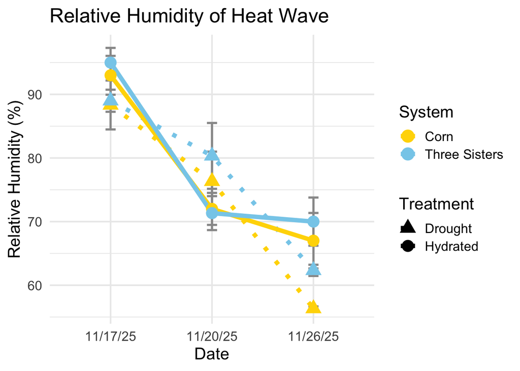

```r
ggplot(
  heatwave_sum,
  aes(
    x = Date,
    y = RH_mean,
    color = System,
    shape = Treatment,
    linetype = Treatment,
                    group = interaction(System, Treatment))) +

    geom_errorbar(aes(ymin = RH_mean - RH_se,
                    ymax = RH_mean + RH_se),
                width = 0.1,
                size = 1,
       alpha = 1,
       color = "gray60",
       linetype = "solid") +
  geom_line(size = 2,
       alpha = 1) +
  geom_point(size = 5,
       alpha = 1) +
  scale_color_manual(values = color_vals) +
  scale_shape_manual(values = shape_vals) +
  scale_linetype_manual(values = linetype_vals) +
  labs(title = "Relative Humidity of Heat Wave",
       x = "Date", y = "Relative Humidity (%)")
```

# Part 9 — Student Task: Make the Heat Wave Growth Plots

➤ **YOU DO THIS:**

```r
# your code here
```

# Part 10 — Discussion Questions

### Growth & Treatment Effects

1. Which species benefited most from nutrient-rich soil in the main experiment?
2. How does the Three Sisters system affect each crop’s growth?
3. Which species showed the largest impact of drought during the heat wave?
4. How do temperature, humidity, and soil moisture trends help explain your growth results?

### Flower and Fruit Production

5. Which species produced the most reproductive structures (flowers, pods, ears, fruits) in the main experiment?
6. How did nutrient treatment (nutrient-poor vs nutrient-rich) affect flower or fruit production for each species?
7. Did the Three Sisters system change reproductive output for any crop?
8. Is reproductive output proportional to vegetative growth? Do the biggest plants also make the most flowers and fruits?

### Plant Health (Greenness)

9. How does greenness (1–3 scale) vary between treatments (nutrient-poor vs nutrient-rich, drought vs watered)?
10. Did the Three Sisters system improve plant health (as measured by greenness)?
11. Which species appears most sensitive to nutrient stress or drought based on greenness scores?

### Synthesis

12. Do patterns in growth, reproduction, and greenness tell a consistent story for each species?
13. Based on the combined evidence, which species seems to benefit most from being in a Three Sisters system?
14. If you were advising a farmer facing nutrient-poor soils or drought, which results from this experiment would be most relevant?

Write brief answers below: